# homework2-RA769687

Italo Carvalho Vianelli Ribeiro

12/06/2020

RA: 769687

```r
library(ggplot2)
data(USArrests)
mydata = USArrests
```

Exercício 1

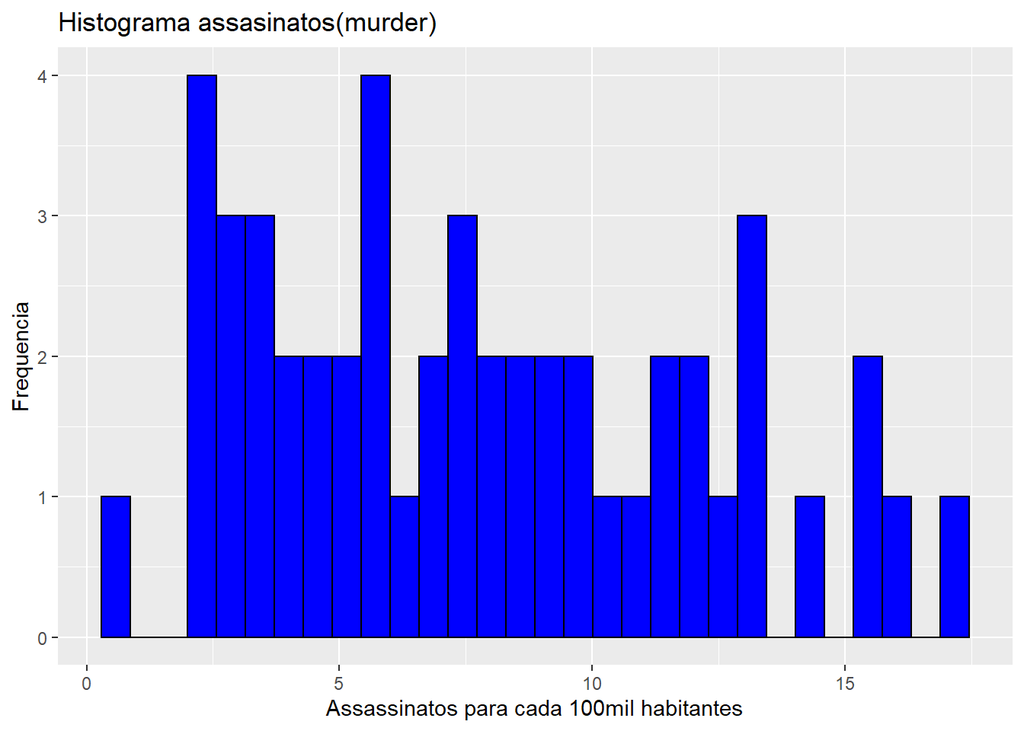

```r
ggplot(data = USArrests) +
geom_histogram(mapping = aes(x = Murder), fill ='blue', color='black') +
labs(x = 'Assassinatos para cada 100mil habitantes',
y = 'Frequencia',
title = 'Histograma assasinatos(murder)')
```

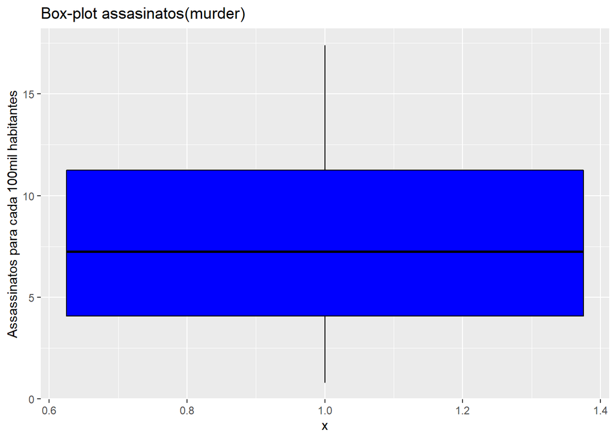

```r
ggplot(data = USArrests) +
geom_boxplot(mapping = aes(x = 1, y = Murder), color = 'black', fill = 'blue')+
labs(y = 'Assassinatos para cada 100mil habitantes',
title = 'Box-plot assasinatos(murder)')
```

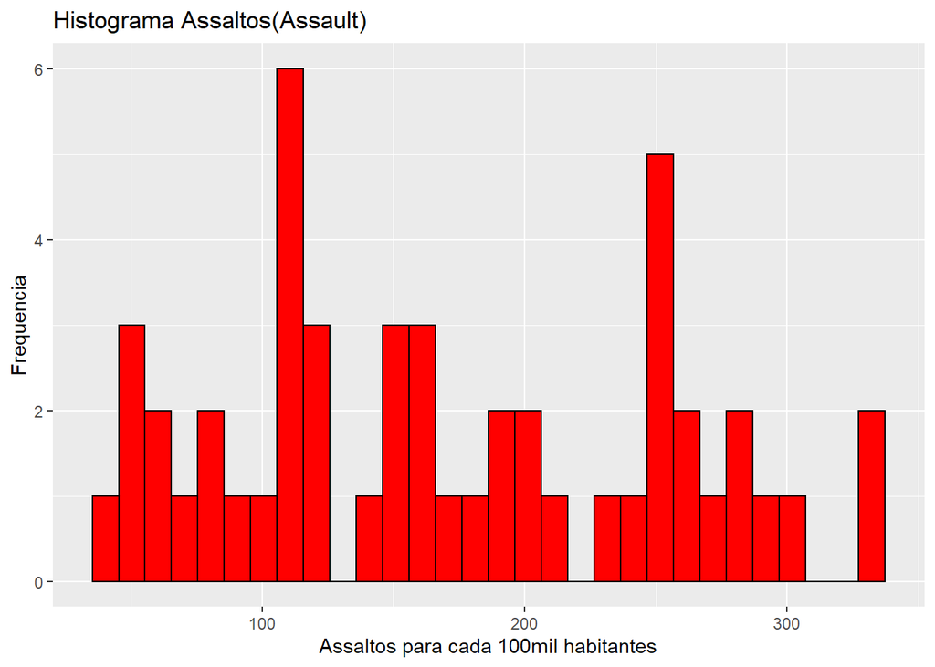

```r
ggplot(data = USArrests) +
geom_histogram(mapping = aes(x = Assault), fill ='red', color='black') +
labs(x = 'Assaltos para cada 100mil habitantes',
y = 'Frequencia',
title = 'Histograma Assaltos(Assault)')
```

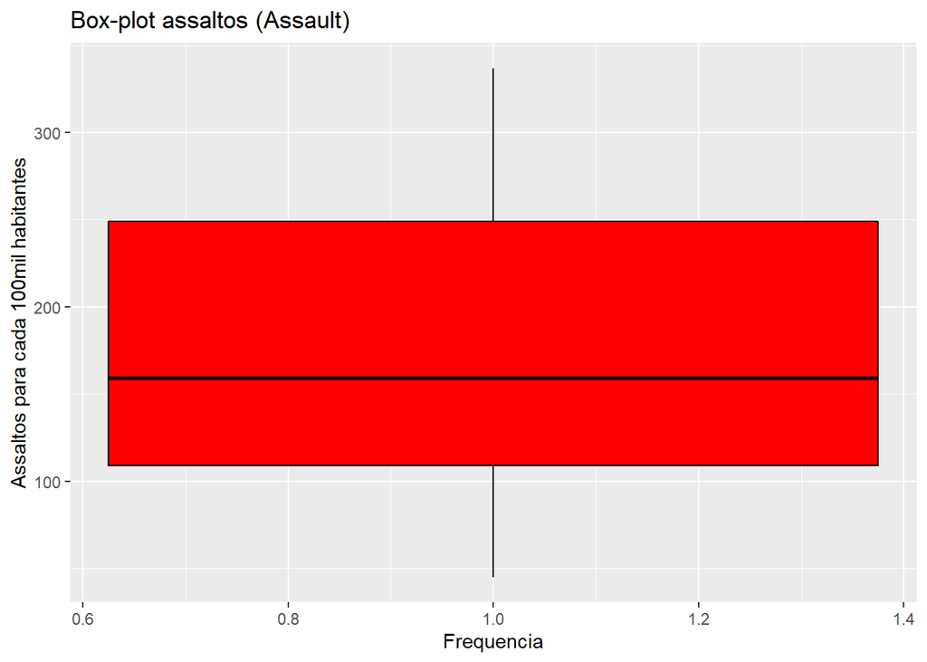

```r
ggplot(data = USArrests) +
geom_boxplot(mapping = aes(x = 1, y = Assault), color = 'black', fill = 'red')+
labs(y = 'Assaltos para cada 100mil habitantes',
x = 'Frequencia',
title = 'Box-plot assaltos (Assault)')
```

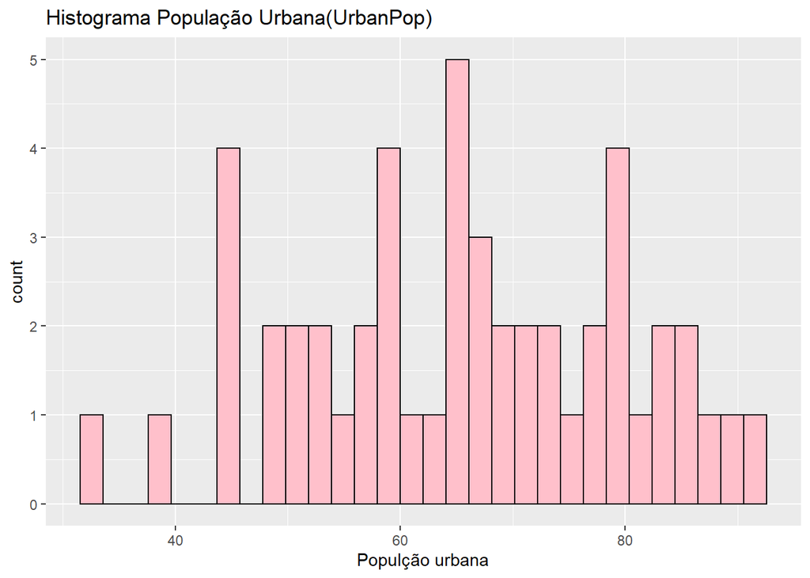

```r
ggplot(data = USArrests) +
geom_histogram(mapping = aes(x = UrbanPop), fill ='pink', color='black') +
labs(x = 'Populção urbana',
title = 'Histograma População Urbana(UrbanPop)')
```

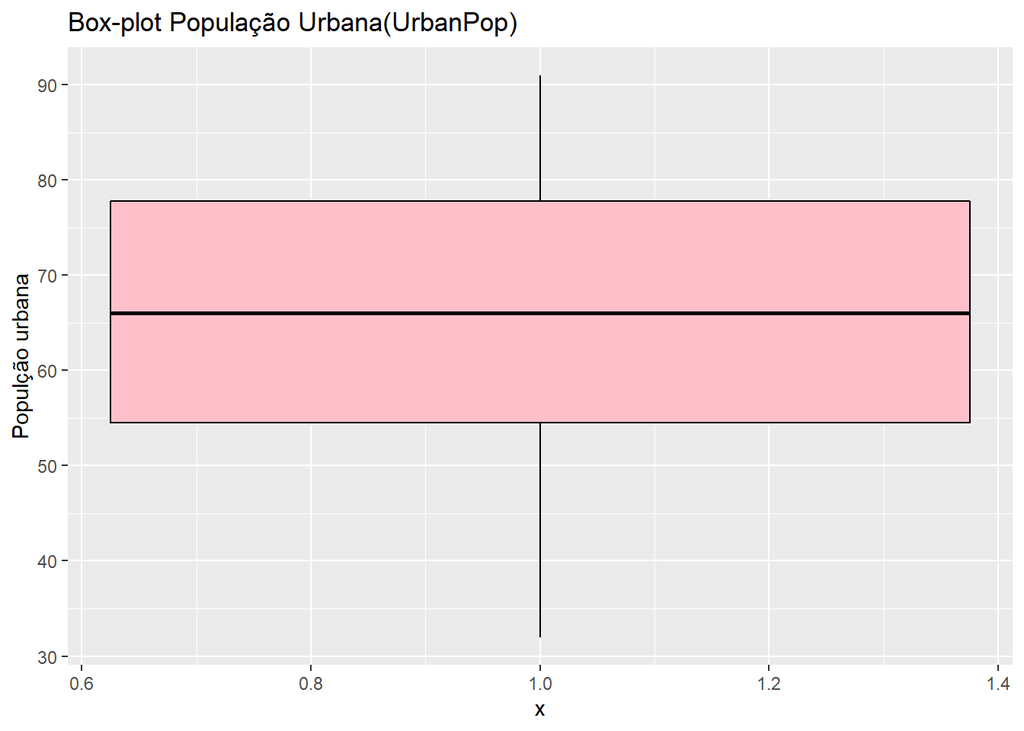

```r
ggplot(data = USArrests) +
geom_boxplot(mapping = aes(x = 1, y = UrbanPop), color = 'black', fill = 'pink')+
labs(y = 'Populção urbana',
title = 'Box-plot População Urbana(UrbanPop)')
```

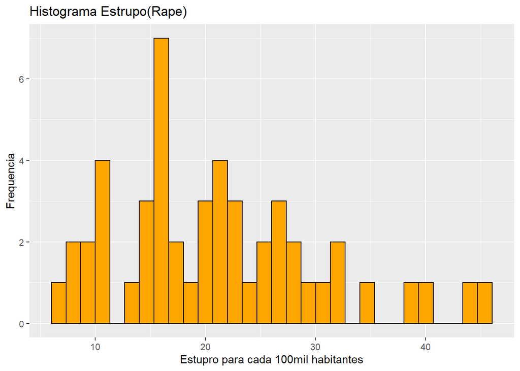

```r
ggplot(data = USArrests) +
geom_histogram(mapping = aes(x = Rape), fill ='orange', color='black') +
labs(x = 'Estupro para cada 100mil habitantes',
y = 'Frequencia',
title = 'Histograma Estrupo(Rape)')
```

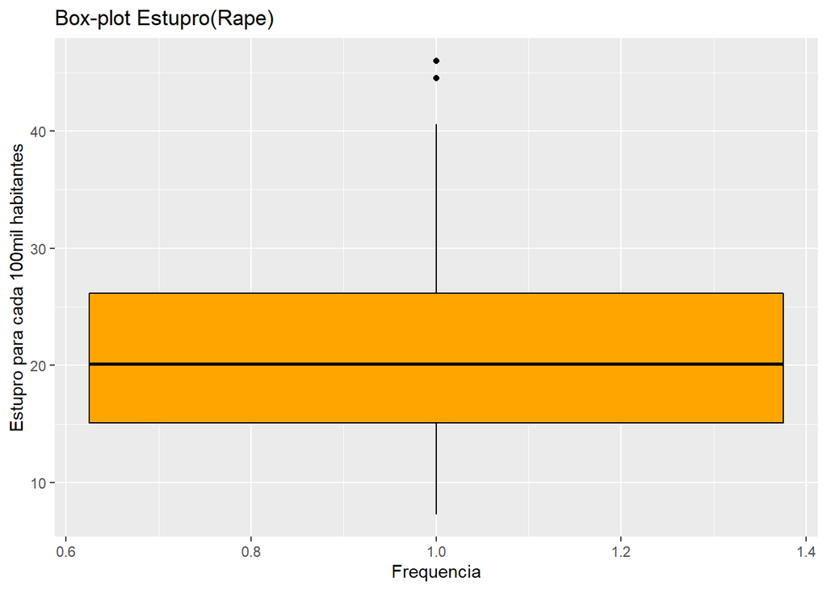

```r
ggplot(data = USArrests) +
geom_boxplot(mapping = aes(x = 1, y = Rape), color = 'black', fill = 'orange')+
labs(y = 'Estupro para cada 100mil habitantes',
x = 'Frequencia',
title = 'Box-plot Estupro(Rape)')
```

Exercicío 2

Resolvi fazer um gráfico a fim de verificar como o nível de assaltos se relaciona com o tamanho da população urbana. Ademais obti a linha relacionando as duas variavéis, e por ela ser crescente pude concluir que de acordo quanto mais população urbana tem o estado nos Estado Unidos, geralmente maiores são os índices de assalto.

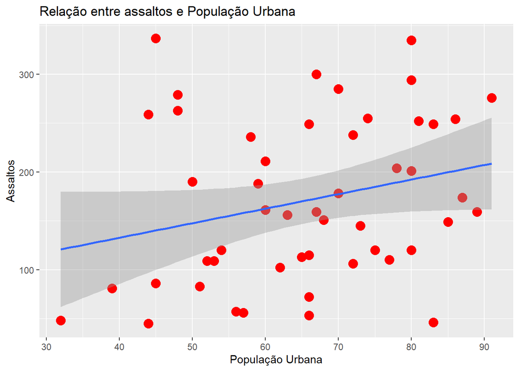

```r
ggplot(mydata, aes(x = UrbanPop, y = Assault)) +
geom_point(color='red', size=4) +
labs(y = "Assaltos",
x = "População Urbana",
title = "Relação entre assaltos e População Urbana")+
geom_smooth( method = "lm")
```

Exercício 3

O conjunto de dados ToothGrowth contém o resultado de um experimento que estuda o efeito da vitamina C no crescimento dentário em 60 porquinhos da Índia. Cada animal recebeu um dos três níveis de dose de vitamina C (0,5, 1 e 2 mg / dia) por um dos dois métodos de entrega (suco de laranja ou ácido ascórbico (uma forma de vitamina C e codificada como VC).

```r
data(ToothGrowth)
myData2 =  ToothGrowth
head(myData2)
```

```
##    len supp dose
## 1  4.2   VC  0.5
## 2 11.5   VC  0.5
## 3  7.3   VC  0.5
## 4  5.8   VC  0.5
## 5  6.4   VC  0.5
## 6 10.0   VC  0.5
```

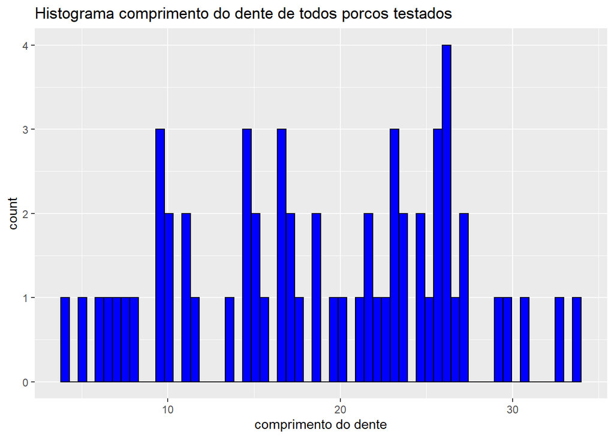

```r
ggplot(myData2) +
geom_histogram(mapping = aes(x = len), bins = 60, fill ='blue', color='black') +
labs(x = 'comprimento do dente',
title = 'Histograma comprimento do dente de todos porcos testados')
```

Verificação da quantidade de doses utilizadas nos testes

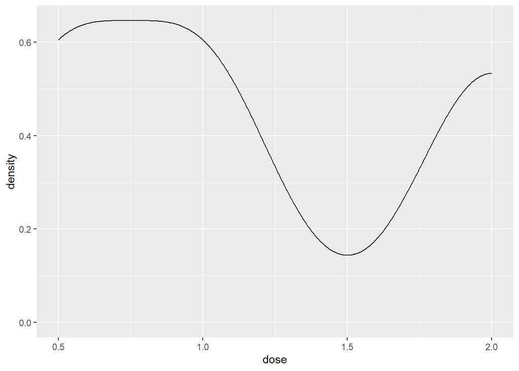

```r
ggplot(data = myData2) +
geom_density(mapping = aes(x = dose), kernel = 'gaussian')
```

Nesse gráfico é possível visualizar que foram obtidos mais resultados de comprimento de dente entre 20 e 30.

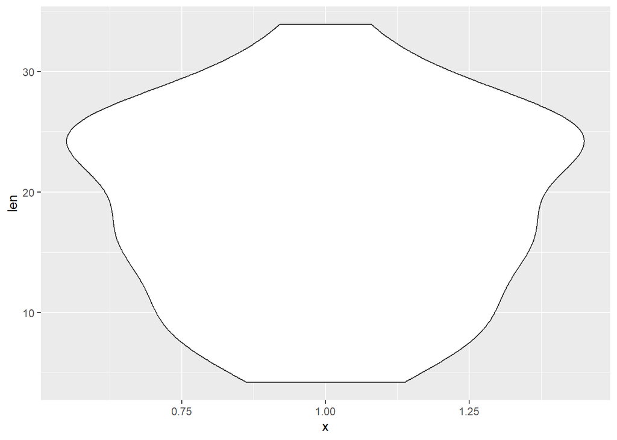

```r
ggplot(data = myData2) +
geom_violin(mapping = aes(x = 1, y = len))
```

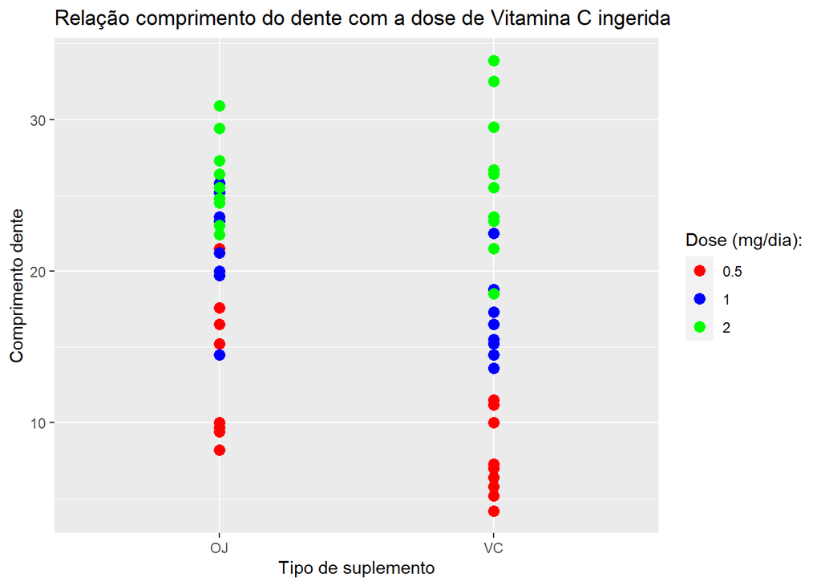

```r
ggplot(myData2) +
geom_point(aes(x = supp, y = len, color = factor(dose)),
size = 3) +
scale_color_manual("Dose (mg/dia):",
values = c("red", "blue", "green"),
labels = c("0.5", "1", "2")) +
labs(title = 'Relação comprimento do dente com a dose de Vitamina C ingerida',
y = 'Comprimento dente',
x = 'Tipo de suplemento')
```

Exercício 4

De acordo com o gráfico realizado foi possivel visualizar que através dos testes feitos pode se observar que em média, o uso do suco de laranja para o crescimento dos dentes é mais eficaz do que a vitamina C (ácido ascórbico) em si

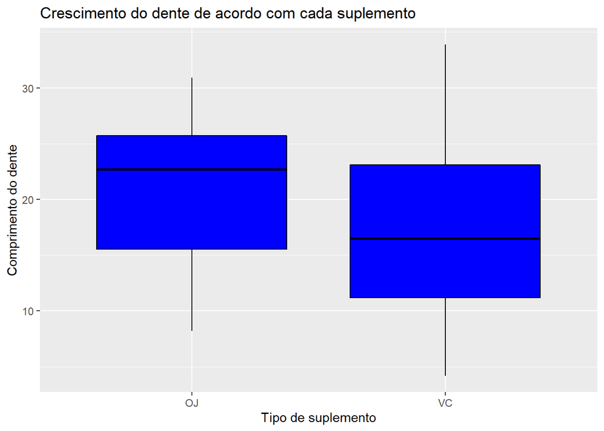

```r
ggplot(data = myData2) +
geom_boxplot(mapping = aes(x = supp, y = len), color = 'black', fill = 'blue')+
labs(y = 'Comprimento do dente', x='Tipo de suplemento',
title = 'Crescimento do dente de acordo com cada suplemento')
```